# Assignment 3

```
## [1] "UMAP n_neighbors=2"
```

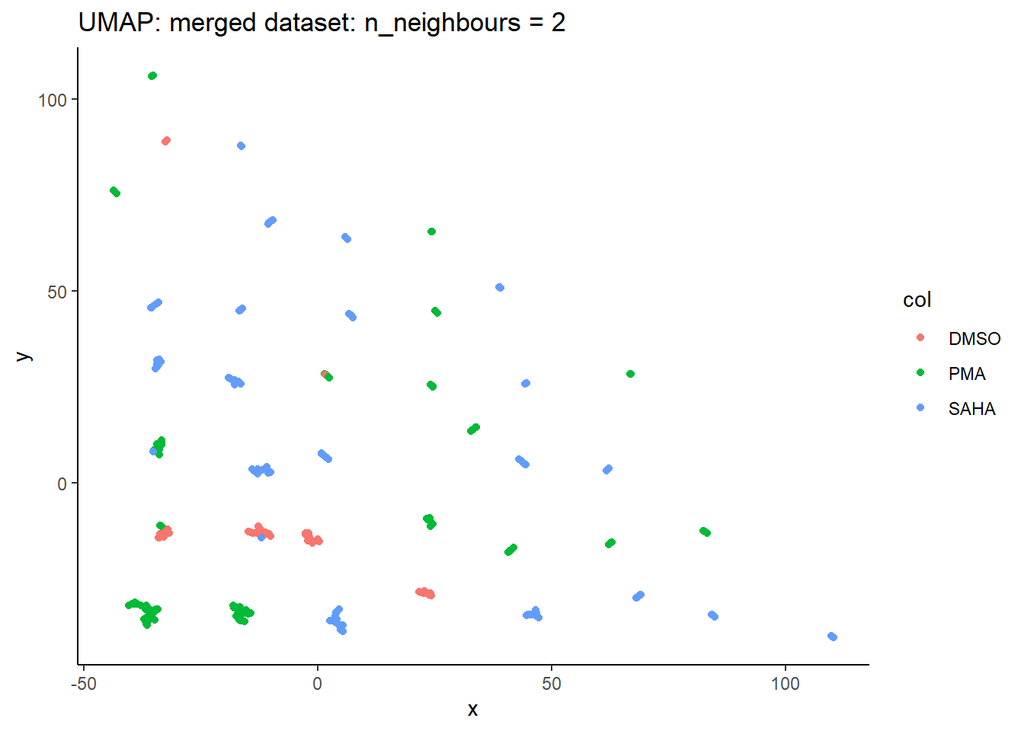

```
## [1] "UMAP n_neighbors=5"
```

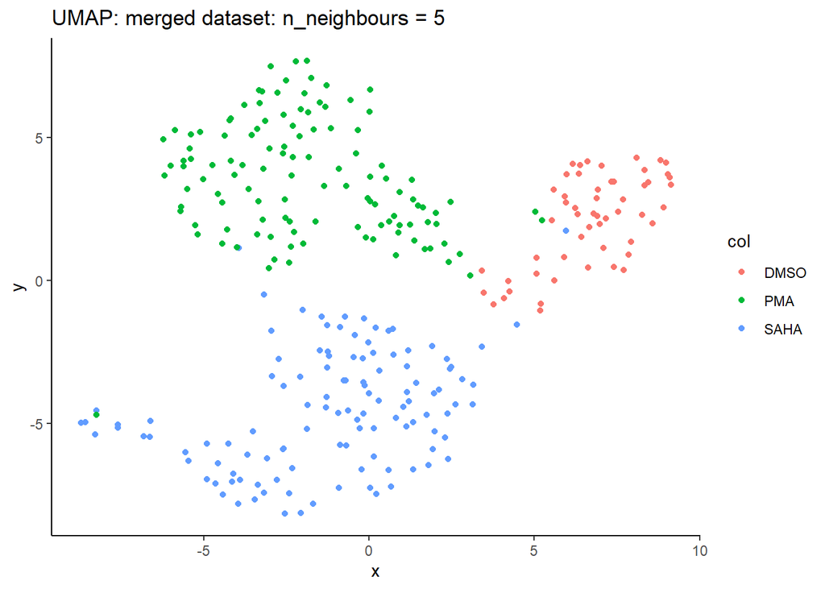

```
## [1] "UMAP n_neighbors=15"
```

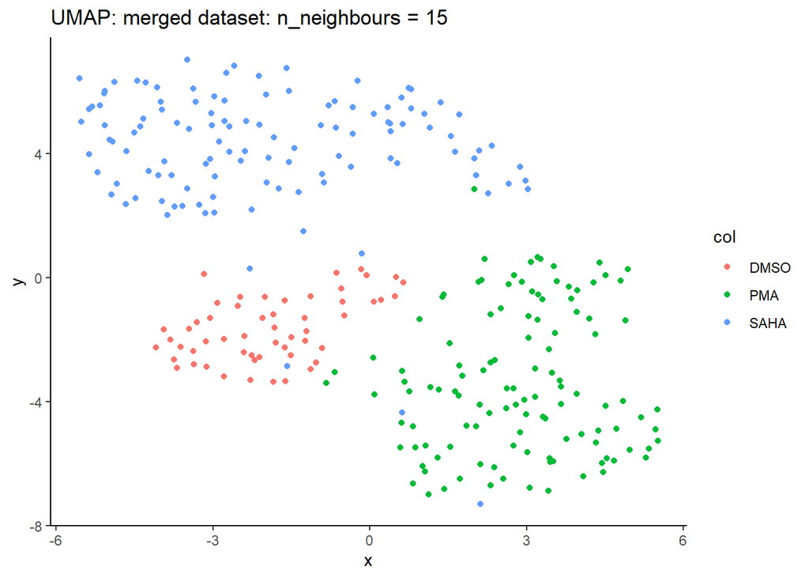

```
## [1] "UMAP n_neighbors=50"
```

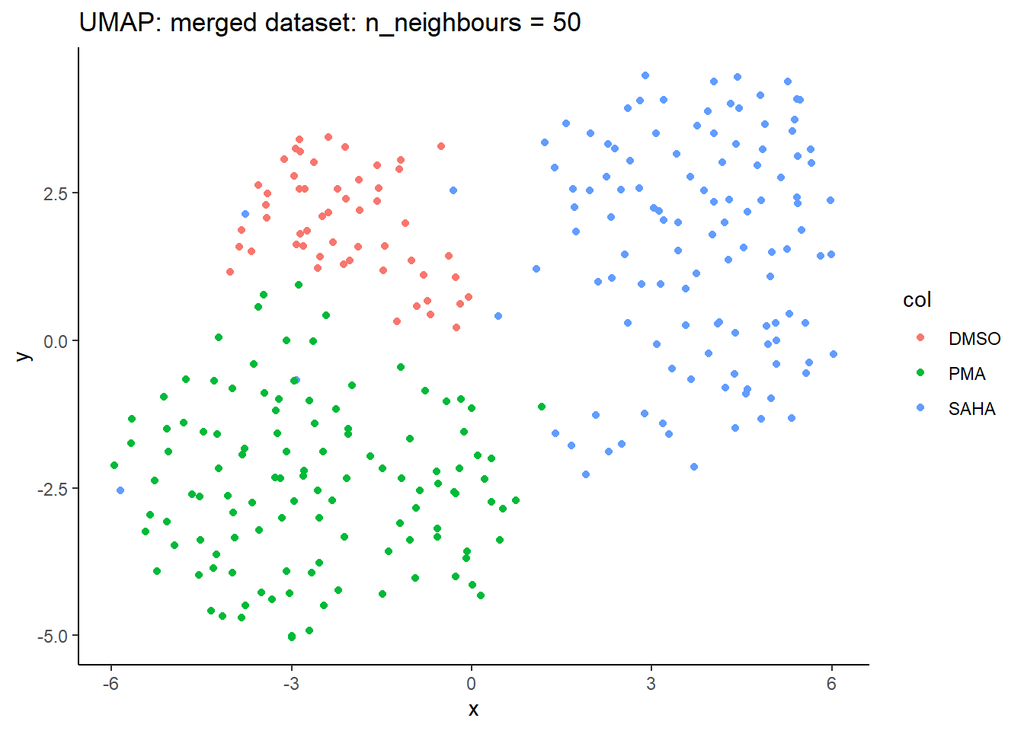

```
## [1] "UMAP n_neighbors=100"
```

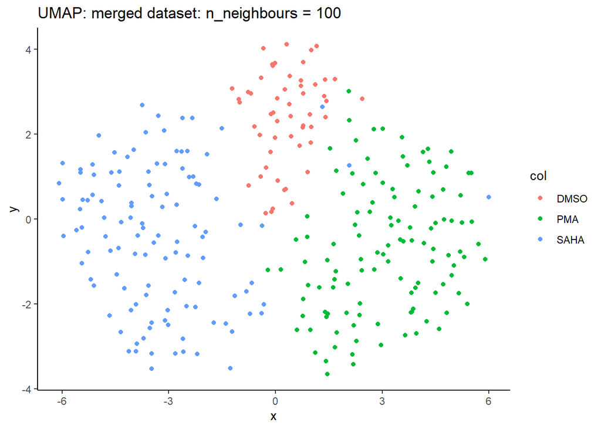

```
## [1] "UMAP n_neighbors=200"
```

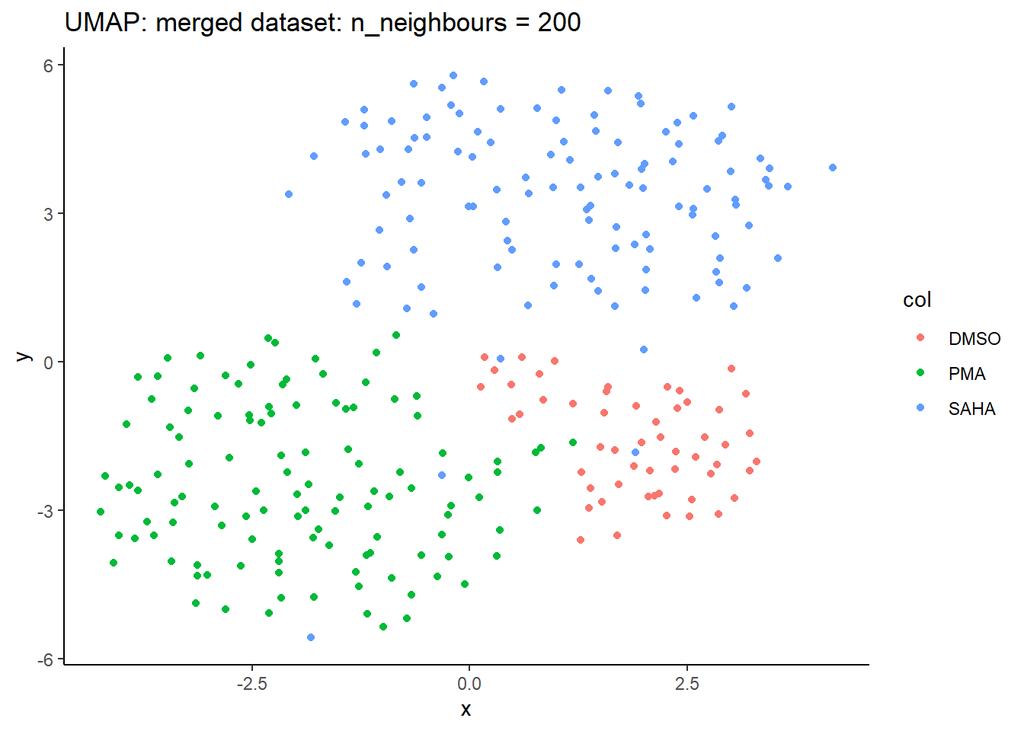

```r
# Explore number of neighbours
for (n_neighbors_values in c(2,5,15,50,100,200)) {
  print(paste0("UMAP n_neighbors=", n_neighbors_values))

  custom.umap.config$n_neighbors = n_neighbors_values

  umap_n <- umap(Y, config = custom.umap.config)

  UMAP_plot <- plot_representation(umap_n$layout[,1],
                    umap_n$layout[,2],
                    treat$drugs,
                    paste0("UMAP: merged dataset: n_neighbours = ", n_neighbors_values))


  print(UMAP_plot)
}
```

```
## [1] "UMAP random_state=2"
```

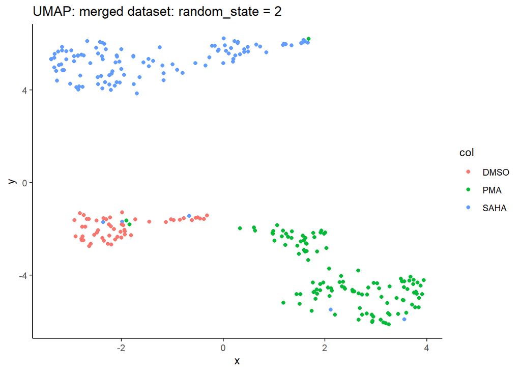

```
## [1] "UMAP random_state=5"
```

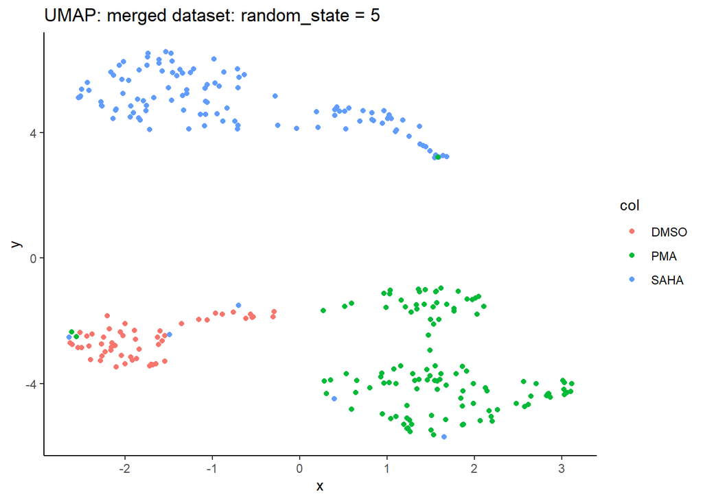

```
## [1] "UMAP random_state=15"
```

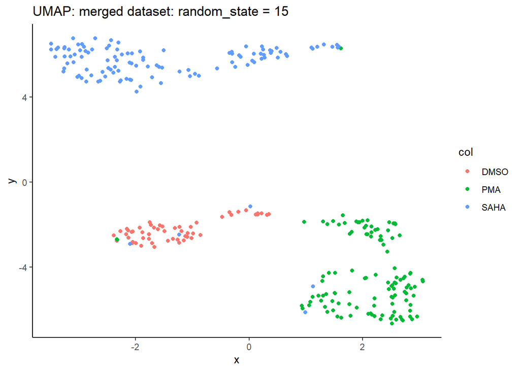

```
## [1] "UMAP random_state=50"
```

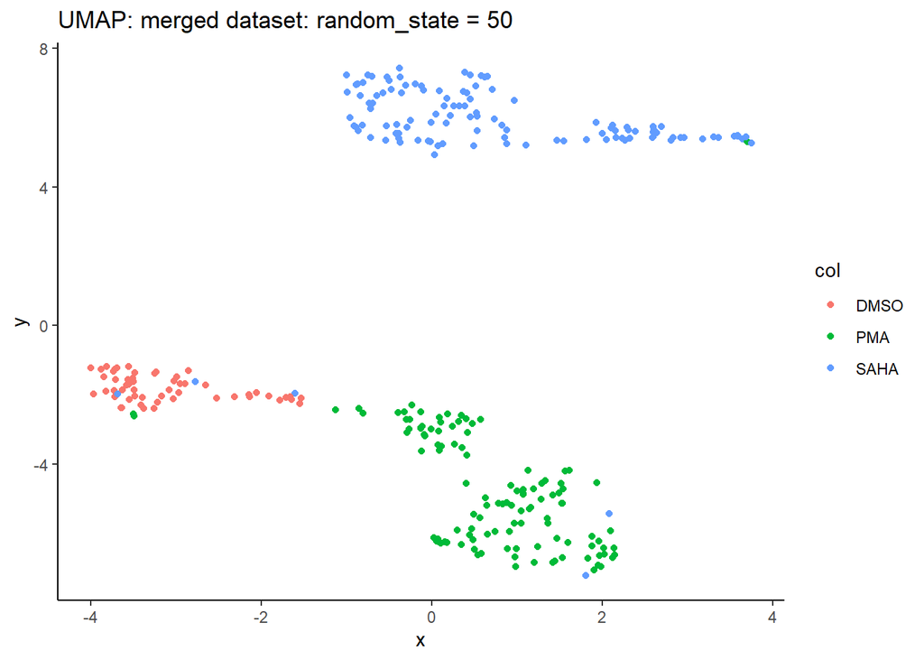

```
## [1] "UMAP random_state=100"
```

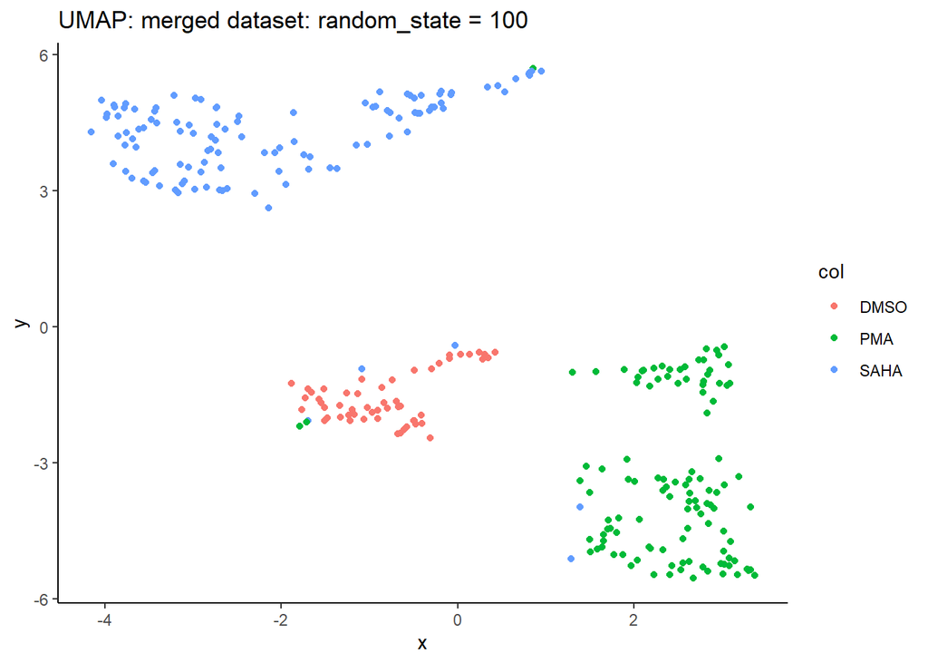

```
## [1] "UMAP random_state=200"
```

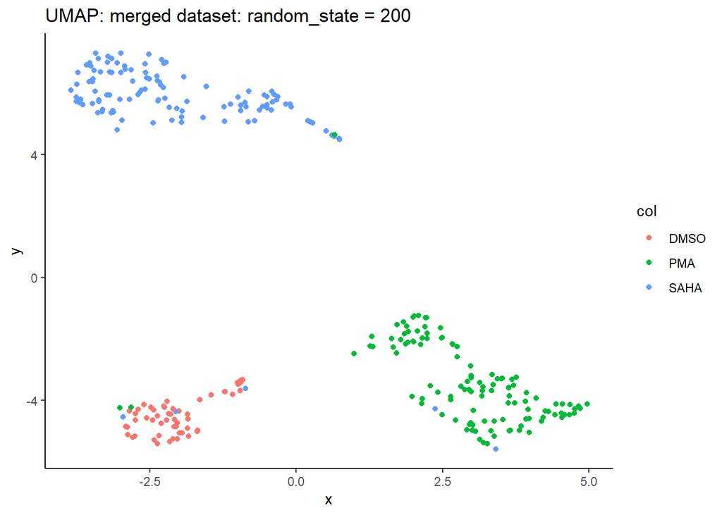

```r
#Exploring random state values
custom.umap.config <- umap::umap.defaults
for (random_state_values in c(2,5,15,50,100,200)) {
  print(paste0("UMAP random_state=", random_state_values))

  custom.umap.config$random_state = random_state_values

  umap_n <- umap(Y, config = custom.umap.config)

  UMAP_plot <- plot_representation(umap_n$layout[,1],
                    umap_n$layout[,2],
                    treat$drugs,
                    paste0("UMAP: merged dataset: random_state = ", random_state_values))


  print(UMAP_plot)
}
```

In the explorations we made above we tested some parameters:  
-the min_dist defines how close points appear in the layout of the plot. We tested it for three values: 0.1, 0.5, 0.9. Low values of `min_dist` lead to more tightly packed clusters, whereas larger values lead to more loose clusters.  
-the `n_neighbours` parameter specifies the number of nearest points to each of the observations in the plot. For `n_neighbours` we tested the following values: 2,5,15,50,100,200. For low values we get many rarefied clusters, while when using higher values we obtain less clusters with more density of the points. So, the main difference is in how we want to analyze our data: a more accurate analisys (first case) or a more general overview (second case).  
-`random state` is a parameter used for initializing the internal random number generator,that allows us to set a random seed state in order to ensure that results are reproduced exactly. This takes longer than the earlier runs with no random_state set.

**QUESTION 10**

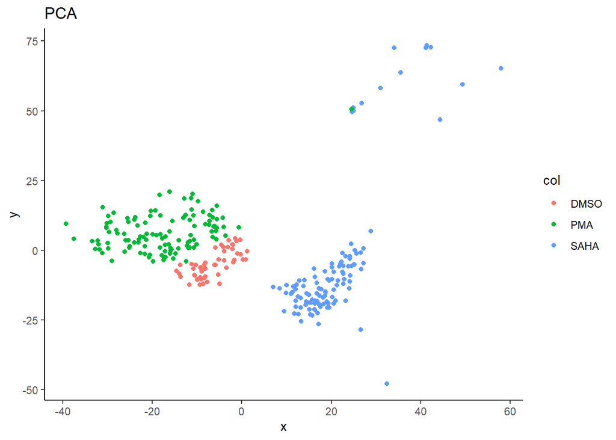

```r
pca_plot <- plot_representation(normpca$x[,1],
                    normpca$x[,2],  treat2$drugs,
                    "PCA")

print(pca_plot)
```

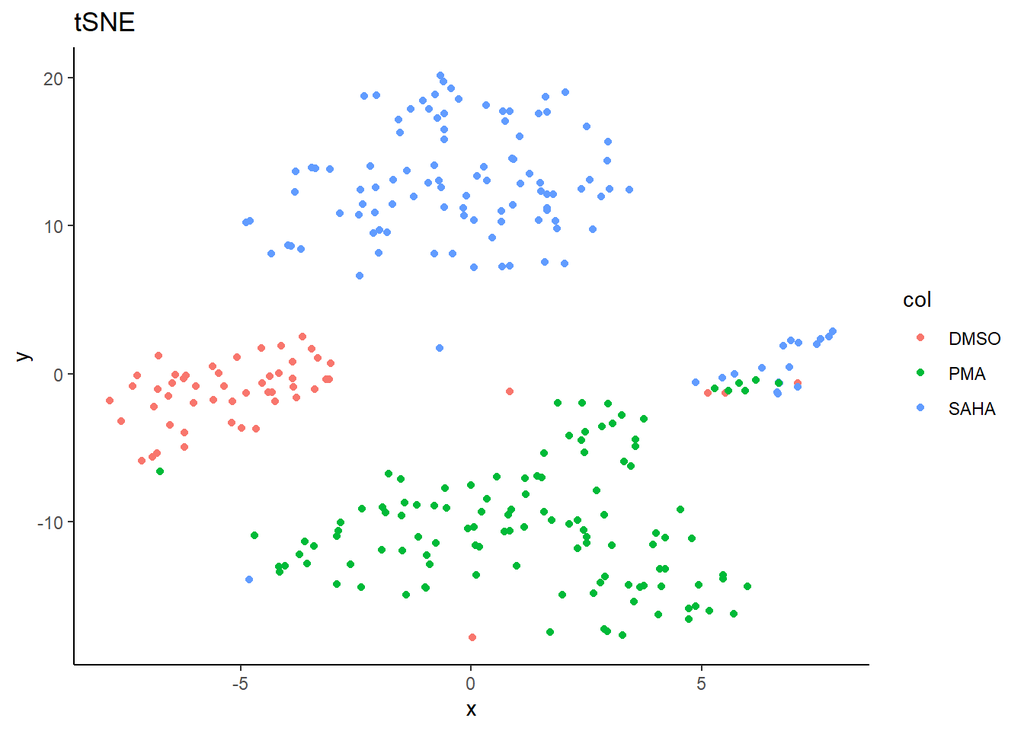

```r
tSNE_plot <- plot_representation(tsne$Y[,1],
                    tsne$Y[,2],  treat$drugs,
                    "tSNE")

print(tSNE_plot)
```

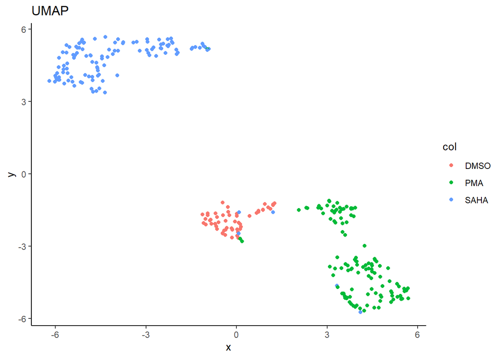

```r
UMAP_plot <- plot_representation(pmerged_dataSet_UMAP$layout[,1],
                    pmerged_dataSet_UMAP$layout[,2],  treat$drugs,
                    "UMAP")

print(UMAP_plot)
```

Providing a plot using each of the three techniques can show us that the three of them bring similar results, with one cluster of points for each *treatment*. In particular though, **PCA** and **UMAP** convey very similar results both showing that DMSO (control) and PMA have a similar effect on the cells and both have a different effect from SAHA. On the other hand, *tSNE* is a bit more different: while still nicely showing the three clusters, their positions and the distances between them are not significant, so they can’t be used to infer similiarities or dissimilarities between the effects of the drugs. In the tSNE plot, we can only get information about single points whithin each cluster (if two points within one cluster are close to each other, they are more similar than two points in the same cluster which are further apart).

Both tSNE and UMAP algorithms exhibit strong local clustering and group similar categories together, but UMAP much more clearly separates these groups of similar categories from each other.

PCA differs from both tSNE and UMAP in that it is the only model in which positions with respect to axes and distances between clusters are directly interpretable.